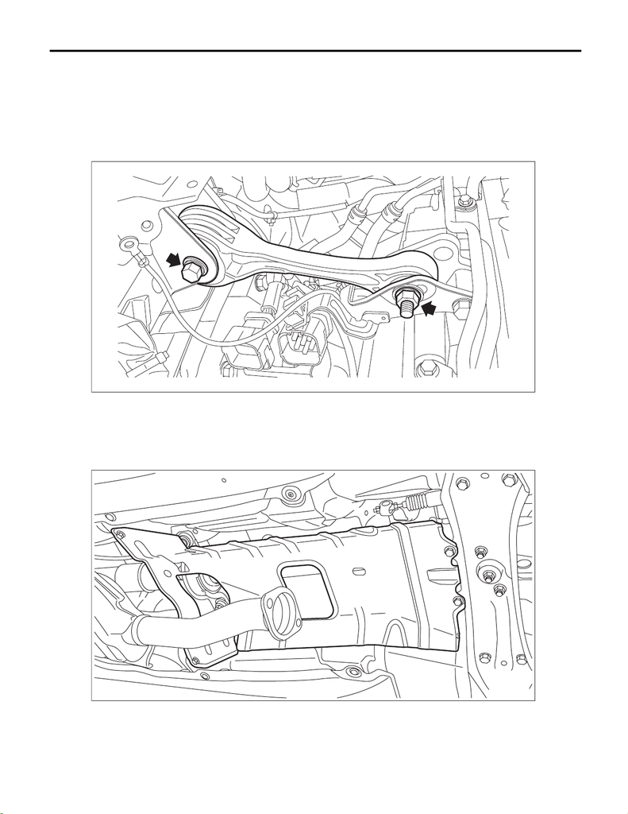

CVT(TR690)-83

Transmission Mounting System

CONTINUOUSLY VARIABLE TRANSMISSION

11.Transmission Mounting System

A: REMOVAL

1. PITCHING STOPPER

1) Disconnect the ground terminal from battery sensor. <Ref. to NT-5, BATTERY, NOTE, Note.>

2) Remove the intercooler. <Ref. to IN(w/o STI)-38, REMOVAL, Intercooler.>

3) Remove the pitching stopper.

2. TRANSMISSION REAR CROSSMEMBER AND REAR CUSHION RUBBER

1) Disconnect the ground terminal from battery sensor. <Ref. to NT-5, BATTERY, NOTE, Note.>

2) Lift up the vehicle.

3) Remove the center exhaust pipe (rear). <Ref. to EX(w/o STI)-35, REMOVAL, Center Exhaust Pipe.>

4) Remove the center exhaust cover.

CVT00490

AT-07743

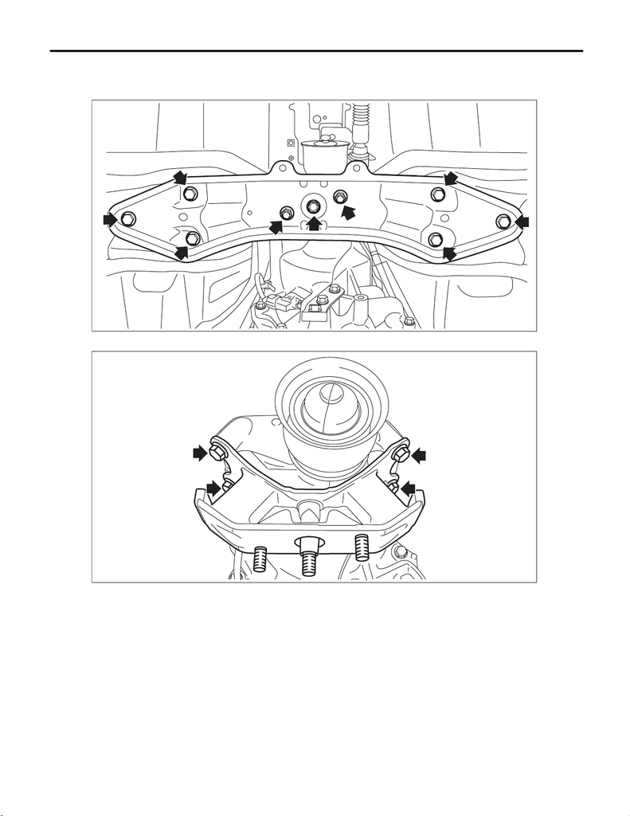

CVT(TR690)-84

Transmission Mounting System

CONTINUOUSLY VARIABLE TRANSMISSION

6) Remove the transmission rear crossmember.

7) Remove the rear cushion rubber.

AT-07744

AT-07338

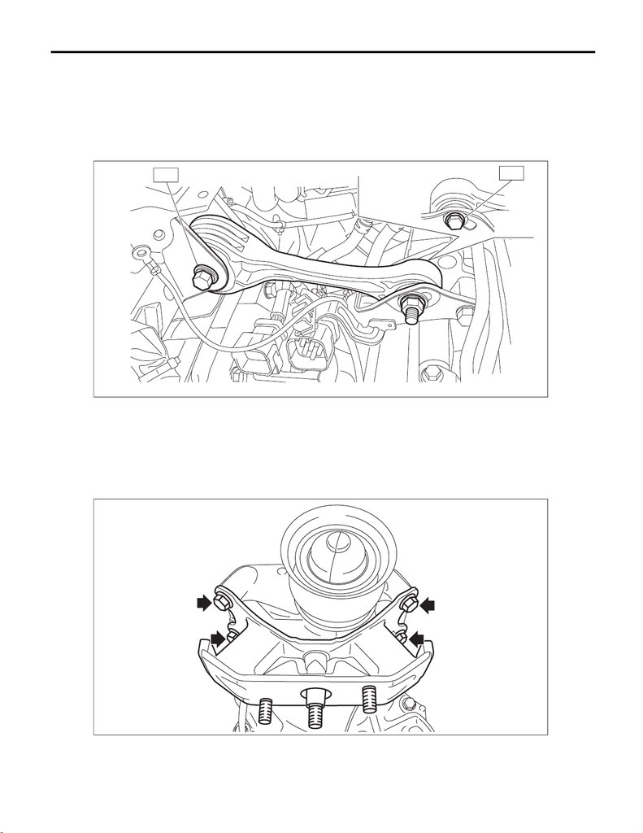

CVT(TR690)-85

Transmission Mounting System

CONTINUOUSLY VARIABLE TRANSMISSION

B: INSTALLATION

1. PITCHING STOPPER

1) Install the pitching stopper.

Tightening torque:

T1: 50 N·m (5.1 kgf-m, 36.9 ft-lb)

T2: 58 N·m (5.9 kgf-m, 42.8 ft-lb)

2) Install the intercooler. <Ref. to IN(w/o STI)-41, INSTALLATION, Intercooler.>

3) Connect the ground terminal to battery sensor. <Ref. to NT-5, BATTERY, NOTE, Note.>

2. TRANSMISSION REAR CROSSMEMBER AND REAR CUSHION RUBBER

1) Install the rear cushion rubber.

Tightening torque:

40 N·m (4.1 kgf-m, 29.5 ft-lb)

CVT00491

T1

T2

AT-07338

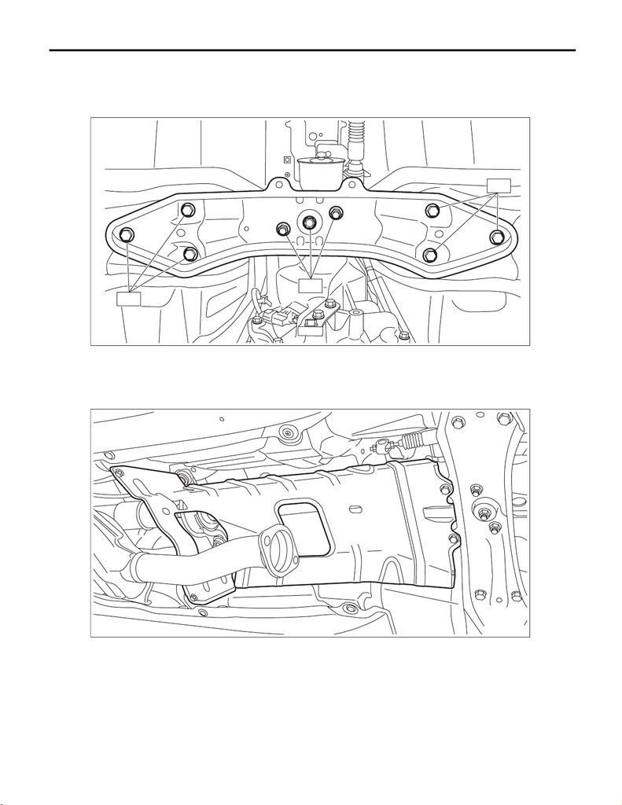

CVT(TR690)-86

Transmission Mounting System

CONTINUOUSLY VARIABLE TRANSMISSION

2) Install the transmission rear crossmember.

Tightening torque:

T1: 35 N·m (3.6 kgf-m, 25.8 ft-lb)

T2: 70 N·m (7.1 kgf-m, 51.6 ft-lb)

3) Remove the transmission jack.

4) Install the center exhaust cover.

Tightening torque:

18 N·m (1.8 kgf-m, 13.3 ft-lb)

5) Install the center exhaust pipe (rear). <Ref. to EX(w/o STI)-41, INSTALLATION, Center Exhaust Pipe.>

6) Connect the ground terminal to battery sensor. <Ref. to NT-5, BATTERY, NOTE, Note.>

C: INSPECTION

• Check the crossmember for bends or damage.

• Check that the cushion rubber is not stiff, cracked or otherwise damaged.

AT-07873

T2

T2

T1

AT-07743